# Visualisation I

## A closer view: the first hour

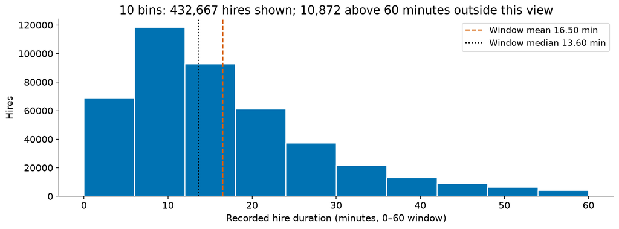

```python
within_hour = durations[durations <= 60]
print(len(within_hour), len(durations) - len(within_hour))
fig, ax = plt.subplots(figsize=(11, 4))
ax.hist(within_hour, bins=10, color="#0072B2", edgecolor="white")
```

**432,667 hires shown; 10,872 above 60 minutes (2.45%) outside this view.** All 199 zeros remain. This viewing choice is not a validated definition of a clean or typical hire.

## The viewing window changes the summaries

| Included hires | n | Mean minutes | Median minutes |
| --- | --- | --- | --- |
| All recorded durations | 443,539 | 22.97 | 14.0 |
| Recorded duration ≤60 minutes | 432,667 | 16.50 | 13.6 |

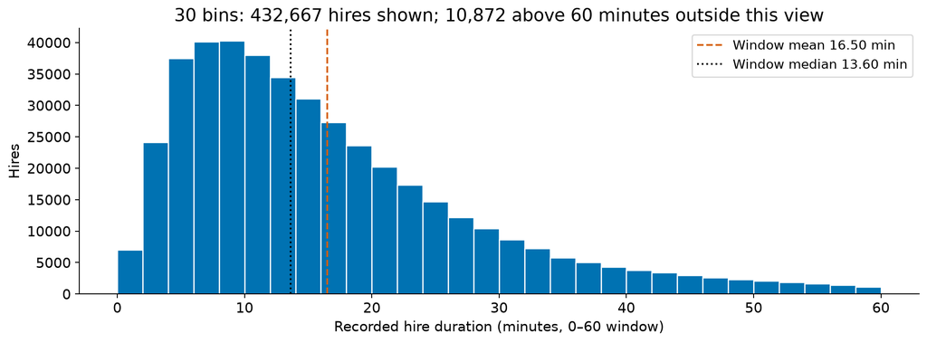

Ten versus thirty bins changes the detail. The **subset rule** changes which hires enter the calculation. Report both decisions and compute each reference line from its stated population.

## Borough rates: one observation per area

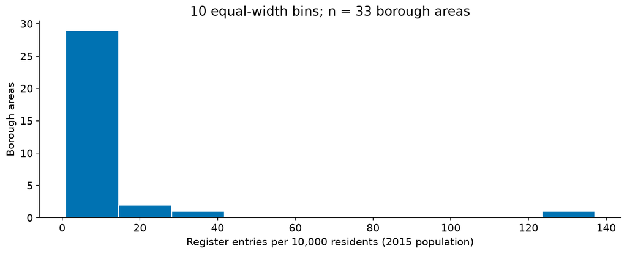

```python
fig, ax = plt.subplots(figsize=(10, 4))
ax.hist(rates.dropna(), bins=10, color="#0072B2", edgecolor="white")
ax.set_xlabel("Register entries per 10,000 residents (2015 population)")
ax.set_ylabel("Borough areas")
```

Most areas have low rates; one lies far to the right. Shape becomes visible, but names disappear.

## Bins are a classification choice

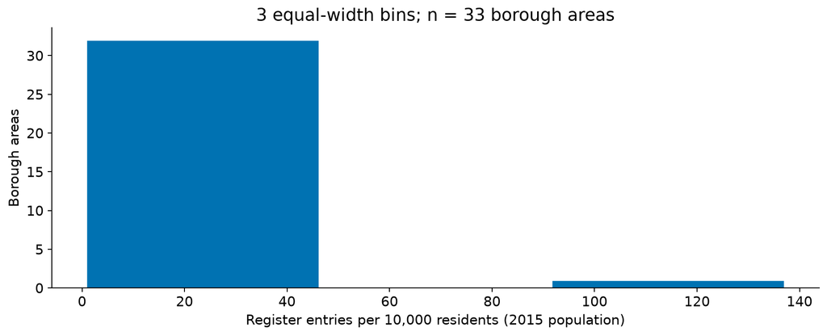

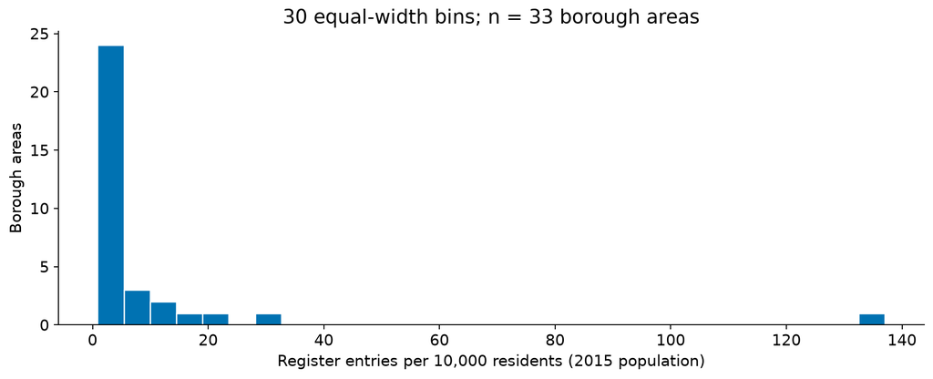

Same **33 values** and numeric range; different boundaries. Three bins hide differences; thirty produce many sparse bins. Neither changes the observations.

With 33 areas, avoid treating every bump as a distinct cultural grouping.

## The City: error, outlier or denominator effect?

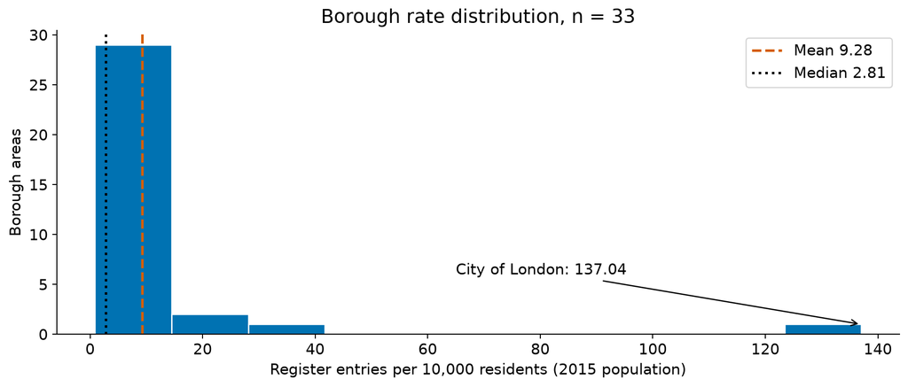

**111 entries / 8,100 residents × 10,000 = 137.04.** A small residential denominator makes this a real but extreme value for our definition.

Investigate source row, formula, units, dates and population served. An outlier is **not automatically an error**.

## Add mean and median lines

```python
ax.axvline(rates.mean(), color="#D55E00", linestyle="--",
           linewidth=2, label=f"Mean {rates.mean():.2f}")
ax.axvline(rates.median(), color="black", linestyle=":",
           linewidth=2, label=f"Median {rates.median():.2f}")
ax.legend()
```

The mean (**9.28**) lies right of the median (**2.81**), pulled towards the high rates. Different line styles preserve the distinction without colour alone.

`axvline()` adds a reference at a numeric x-value. Add lines to the histogram’s existing `ax` before saving `fig`.

## Sensitivity to one borough

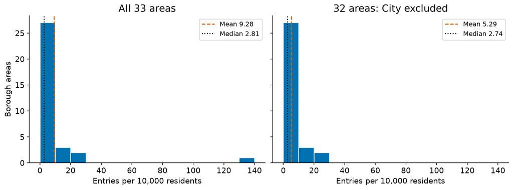

| Areas included | n | Mean | Median |
| --- | --- | --- | --- |
| All | 33 | 9.28 | 2.81 |
| City excluded | 32 | 5.29 | 2.74 |

A **sensitivity check**, not a corrected dataset. Exclusion changes the population described.

## Recompute, rather than hide

```python
without_city = borough_context.loc[
    borough_context["borough_name"].ne("City of London"),
    "venues_per_10k_residents"]
print(without_city.agg(["count", "mean", "median"]))
# count 32; mean 5.2878125; median 2.735
```

Changing axis limits only hides a plotted value; it does not remove it from `rates.mean()`. A sensitivity calculation requires an explicit subset and a stated reason.

## Reading the London histogram

| Feature | Observed result | Limit |
| --- | --- | --- |
| Centre | median 2.81; mean 9.28 | no single rate describes every area |
| Spread | IQR 6.35; range 136.16 | range dominated by City |
| Shape | long right tail | exact bumps depend on bins |
| Unusual case | City at 137.04 | denominator omits workers/visitors |

This is a distribution of **borough-area rates**, with one observation per area. It is not a distribution of residents’ cultural experiences.

## Counts, density and transformations

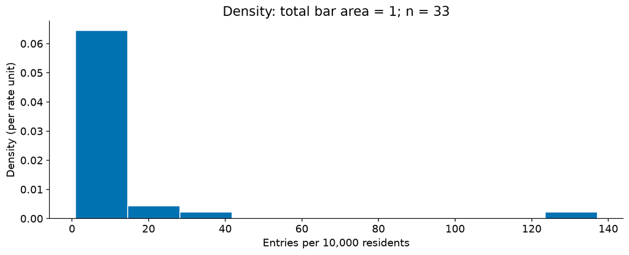

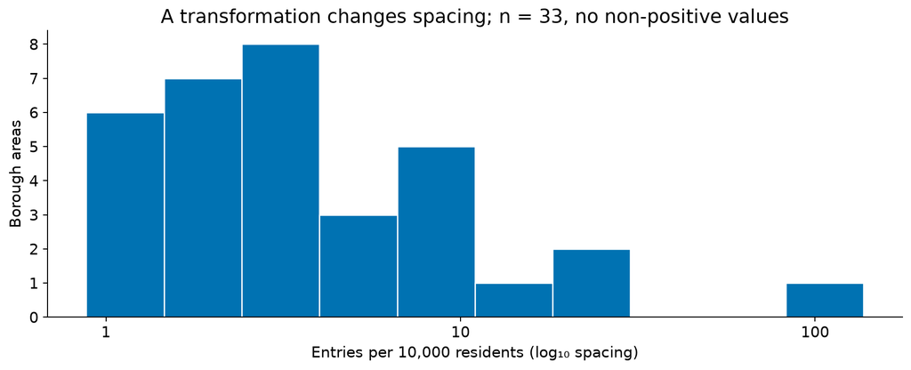

**`density=True`:** height = count / (n × bin width). Total **area**, not total height, is one. A smooth density curve is an estimate, not extra data.

**Log transformation:** equal distances represent ratios. Label the changed scale and check zeros/negatives first.

## Histogram best practices

- State observation unit, numeric units, **n** and missing count.
- Try multiple bin settings; report the setting used.
- Hold bin edges and scales fixed when comparing groups.
- Distinguish count, percentage and density axes.
- Investigate unusual values before exclusion.
- Label transformations or restricted plotting ranges.
- Describe observed shape; do not assume normality.

Here: **33 areas, zero missing rates, right skew, City retained**.

# Saving and applying figures

1. **Save the named figure:** PNG for raster output, SVG or PDF for vector output.
2. **Open the export:** check labels, units and readability.
3. **Write a caption:** source, observation unit, denominator and limits.
4. **Make a supported claim:** connect the visual pattern to the data it represents.

## Save the figure from the notebook

```python
from pathlib import Path
Path("figures").mkdir(exist_ok=True)
fig.savefig("figures/borough_rates.png", dpi=200, bbox_inches="tight")
fig.savefig("figures/borough_rates.svg", bbox_inches="tight")
print(Path("figures/borough_rates.png").is_file())
print(Path("figures/borough_rates.svg").is_file())
```

**PNG:** raster for slides/web. 10 × 4 inches at 200 dpi gives about 2,000 × 800 pixels before tight cropping.

**SVG/PDF:** scalable vector linework and text. Open exports to check labels. `savefig()` writes the file; no separate device-closing step is required.

## What the charts allow us to say

- Archives is the largest **register category**, with 544 entries.
- Westminster leads counts; City leads resident and area rates, with different gaps.
- Havering’s ten library entries form 45.5% of a small total of 22.
- Full recorded hire durations have mean **22.97** and median **14.0 minutes**; a first-hour view changes both the included hires and the summaries.
- Borough resident rates are strongly right-skewed: mean 9.28, median 2.81; City is influential.

These findings depend on **units, definitions, coverage, dates and denominators**. They do not rank cultural value or establish residents’ access.

## Resources

- [Matplotlib gallery](https://matplotlib.org/stable/gallery/) and [pandas plotting guide](https://pandas.pydata.org/docs/user_guide/visualization.html)
- Edward Tufte, *The Visual Display of Quantitative Information* (2001)
- Alberto Cairo, *The Truthful Art* (2016)
- [ColorBrewer](https://colorbrewer2.org/) and [Data Visualisation Catalogue](https://datavizcatalogue.com/)
- [Du Bois visualisation resources](https://www.dignityanddebt.org/projects/du-boisian-resources/)
- D’Ignazio and Klein, [*Data Feminism*](https://data-feminism.mitpress.mit.edu/)

# Live coding and exercises

1. **Reproduce the lecture:** venue bars, borough rates and crosstab charts.
2. **Reuse Week 5 grouping:** turn bike-hire counts and duration summaries into bars.
3. **Inspect distributions:** bins, missingness, extreme values and viewing windows.
4. **Apply and report:** explain a new comparison and save a readable figure.

## Exercise 1: bars and denominators

1. Plot all venue-type frequencies horizontally, with a correct count-axis label.
2. Identify the largest category. Why is this not a count of distinct places?
3. Draw borough counts and entries per 10,000 residents in separate figures.
4. Name the leader in each; write a sentence explaining the change.
5. Compare per-km² rates. Which question does each denominator answer?

Include the population year and a limit on what the rates measure.

## Exercise 2: which chart answers the question?

1. Make the four-borough crosstab: Libraries, both music labels and Other.
2. Draw stacked, grouped and proportional versions.
3. Choose a chart for **“What is Hackney’s recorded entry mix?”** Explain why.
4. Label totals; explain Havering’s 45.5% with numerator and denominator.
5. Retain only the three named types before normalising. Why does Havering become 100% Libraries?

Why can these entry counts still not be added as distinct places?

## Exercise 3: grouped hires and their distribution

1. Reuse `groupby()` on `bike_model`: count hires and calculate mean/median `duration_min`.
2. Draw grouped bars of those two summaries. Keep each group’s count beside the chart.
3. Inspect all durations, then draw the lecture’s **0–60 minute window** with two bin settings.
4. Report included/excluded counts; retain zeros. Calculate reference lines from the stated subset.
5. Explain why mean and median may order groups differently, and why neither establishes speed or trip purpose.

Use the Week 5 trip file and grouping pattern. The viewing window is an explicit analytical choice, not a validated cleaning rule.

## Exercise 4: a distribution and an unusual case

1. Check rate missingness; run `describe()`.
2. Calculate IQR and range with units.
3. Make histograms with two bin settings. What persists; what changes?
4. Add mean and median lines with different styles.
5. Check City’s numerator/denominator; recompute without it and report both n values.
6. Explain why valid arithmetic can still be a limited measure of access.

## Exercise 5: save and inspect

1. Save a labelled figure as PNG and SVG; check both files exist.
2. Open both. Check units, legend, clipping and report-size readability.
3. Write a caption naming the observation unit, release, denominator, missing count and one limit.

**Own project data:** make a useful bar plot and histogram, each with a sentence about what it shows and cannot establish. If no suitable numeric measure exists, explain what additional data are needed rather than plotting an identifier.